# PRTree: Exploratory Semi-Synthetic Studies

Sensitivity Analyses: Standard Missingness vs. Two-Tail Selection in Strong Predictors

PRTree Paper Project

2026-11-10

## 1 Executive Summary

This report compiles the **exploratory semi-synthetic simulation experiments** that served as stepping stones prior to the final specification adopted in Section 6 of the paper (*Upper-Tail MNAR Missingness*):

1. **Scenario 3 (`results_semisynthetic_mech/`):** Missing values are induced across **all predictors** ($p$) under standard MCAR, MAR, and two-tail MNAR mechanisms.
2. **Scenario 2 (`results_semisynthetic_strong/`):** Missingness is selectively injected into the **strongest predictors** ($\lceil p/2 \rceil$ highest correlation with $y$), removing observations from **both tails** (lowest and highest values) under MNAR.
3. **Relation to Scenario 1 (Main Paper - Section 6):** Scenario 1 refines Scenario 2 by restricting the MNAR mechanism to the **upper tail only** in the strongest predictors (simulating detection/saturation thresholds), which represents the most realistic and asymmetric degradation benchmark.

Both exploratory experiments evaluate the three benchmark datasets with complete covariates (**Auto MPG**, **Ozone**, and **Concrete**) across missingness rates $r \in \{10\%, 25\%, 40\%\}$ over 10 independent replications and 5 folds (50 evaluation runs per condition). Both can be reproduced via `07 - Semi-synthetic study.R`.

## 2 1. Exploratory Baseline: Missingness Across All Predictors (Scenario 3)

In this study (`results_semisynthetic_mech/`), missing values were induced across all predictors indiscriminately.

### 2.1 Relative Prediction Error vs. Complete-Data Benchmark

Relative error is defined as:
$$\Delta_{\text{full}} = \frac{\text{RMSE} -
\text{RMSE}_{\text{PR-full}}}{\text{RMSE}_{\text{PR-full}}}$$

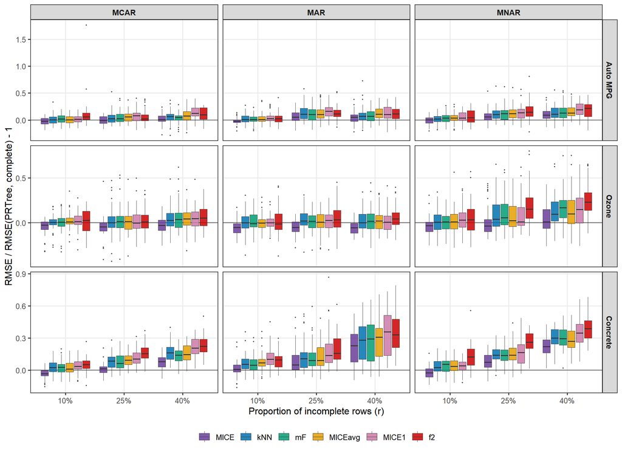

### 2.2 Win-Rate Heatmaps (PR-f2 vs. Competitors)

Pairwise win rate represents the proportion of folds in which `PR-f2` achieved a lower RMSE than each respective competitor:

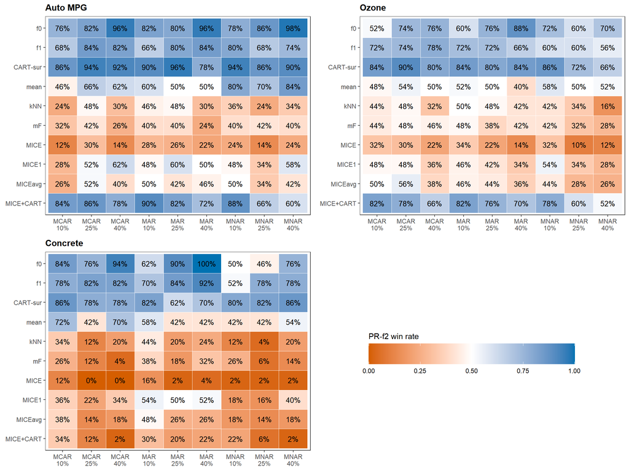

### 2.3 Median Relative Error Summary Table

Scenario 3 (All Predictors): Median (IQR) of relative error for top specifications across datasets. Best (lowest) median error in bold.

| Dataset | Mechanism | Rate | MICE | MICE1 | MICEavg | f2 | kNN | mF |
| --- | --- | --- | --- | --- | --- | --- | --- | --- |
| Auto MPG | MCAR | 10% | **-0.03** (0.10) | 0.01 (0.10) | 0.01 (0.11) | 0.06 (0.12) | 0.01 (0.12) | 0.02 (0.12) |
| Auto MPG | MCAR | 25% | **-0.01** (0.12) | 0.08 (0.15) | 0.06 (0.13) | 0.02 (0.11) | 0.03 (0.13) | 0.03 (0.14) |
| Auto MPG | MCAR | 40% | **0.01** (0.10) | 0.13 (0.15) | 0.07 (0.15) | 0.10 (0.21) | 0.07 (0.11) | 0.05 (0.08) |
| Auto MPG | MAR | 10% | **-0.02** (0.05) | 0.02 (0.09) | 0.01 (0.09) | 0.02 (0.11) | 0.01 (0.11) | 0.01 (0.08) |
| Auto MPG | MAR | 25% | **0.05** (0.14) | 0.16 (0.16) | 0.10 (0.15) | 0.11 (0.12) | 0.11 (0.19) | 0.10 (0.19) |
| Auto MPG | MAR | 40% | **0.05** (0.12) | 0.10 (0.20) | 0.11 (0.17) | 0.12 (0.18) | 0.07 (0.13) | 0.07 (0.17) |
| Auto MPG | MNAR | 10% | **0.01** (0.10) | 0.04 (0.14) | 0.04 (0.09) | 0.04 (0.21) | 0.02 (0.10) | 0.04 (0.12) |
| Auto MPG | MNAR | 25% | **0.06** (0.12) | 0.13 (0.16) | 0.12 (0.15) | 0.15 (0.18) | 0.10 (0.14) | 0.12 (0.17) |
| Auto MPG | MNAR | 40% | **0.09** (0.13) | 0.19 (0.20) | 0.13 (0.15) | 0.22 (0.22) | 0.11 (0.17) | 0.13 (0.18) |
| Ozone | MCAR | 10% | **-0.03** (0.09) | 0.01 (0.10) | 0.01 (0.07) | 0.03 (0.22) | 0.00 (0.06) | 0.01 (0.09) |
| Ozone | MCAR | 25% | **-0.05** (0.09) | -0.00 (0.15) | 0.01 (0.14) | 0.01 (0.15) | -0.00 (0.12) | 0.01 (0.13) |
| Ozone | MCAR | 40% | **-0.03** (0.11) | 0.04 (0.16) | 0.04 (0.14) | 0.05 (0.19) | 0.03 (0.14) | 0.03 (0.16) |
| Ozone | MAR | 10% | **-0.05** (0.10) | -0.00 (0.08) | -0.00 (0.09) | -0.01 (0.17) | 0.00 (0.13) | -0.01 (0.13) |
| Ozone | MAR | 25% | **-0.05** (0.11) | 0.03 (0.14) | 0.00 (0.15) | 0.03 (0.18) | 0.02 (0.13) | 0.02 (0.14) |
| Ozone | MAR | 40% | **-0.06** (0.11) | 0.01 (0.15) | 0.02 (0.15) | 0.04 (0.13) | 0.00 (0.15) | 0.02 (0.16) |
| Ozone | MNAR | 10% | **-0.03** (0.10) | 0.03 (0.16) | 0.01 (0.16) | 0.03 (0.23) | 0.01 (0.17) | 0.01 (0.14) |
| Ozone | MNAR | 25% | **-0.04** (0.13) | 0.01 (0.20) | 0.02 (0.22) | 0.15 (0.23) | 0.04 (0.24) | 0.06 (0.23) |
| Ozone | MNAR | 40% | **0.01** (0.21) | 0.15 (0.28) | 0.10 (0.26) | 0.23 (0.20) | 0.10 (0.21) | 0.17 (0.20) |
| Concrete | MCAR | 10% | **-0.03** (0.05) | 0.04 (0.07) | 0.01 (0.08) | 0.05 (0.07) | 0.02 (0.08) | 0.03 (0.07) |
| Concrete | MCAR | 25% | **0.02** (0.05) | 0.11 (0.10) | 0.09 (0.08) | 0.16 (0.10) | 0.09 (0.09) | 0.06 (0.11) |
| Concrete | MCAR | 40% | **0.08** (0.09) | 0.21 (0.14) | 0.15 (0.13) | 0.22 (0.12) | 0.16 (0.11) | 0.14 (0.09) |
| Concrete | MAR | 10% | **0.01** (0.07) | 0.10 (0.11) | 0.07 (0.06) | 0.10 (0.10) | 0.05 (0.09) | 0.05 (0.10) |
| Concrete | MAR | 25% | **0.05** (0.14) | 0.14 (0.17) | 0.09 (0.17) | 0.16 (0.19) | 0.11 (0.14) | 0.09 (0.12) |
| Concrete | MAR | 40% | **0.23** (0.26) | 0.36 (0.38) | 0.31 (0.26) | 0.33 (0.26) | 0.28 (0.30) | 0.29 (0.34) |
| Concrete | MNAR | 10% | **-0.02** (0.08) | 0.04 (0.07) | 0.04 (0.09) | 0.12 (0.15) | 0.03 (0.09) | 0.05 (0.10) |
| Concrete | MNAR | 25% | **0.07** (0.11) | 0.16 (0.17) | 0.14 (0.11) | 0.26 (0.14) | 0.14 (0.09) | 0.14 (0.10) |
| Concrete | MNAR | 40% | **0.22** (0.12) | 0.35 (0.17) | 0.27 (0.15) | 0.39 (0.16) | 0.30 (0.13) | 0.29 (0.14) |

## 3 2. Sensitivity Analysis: Missingness in Strong Predictors (Scenario 2)

In this study (`results_semisynthetic_strong/`), missingness is concentrated selectively in the **strongest half of the predictors** ($\lceil p/2 \rceil$), removing observations from **both tails** (lowest and highest values) under MNAR.

### 3.1 Relative Prediction Error vs. Complete-Data Benchmark

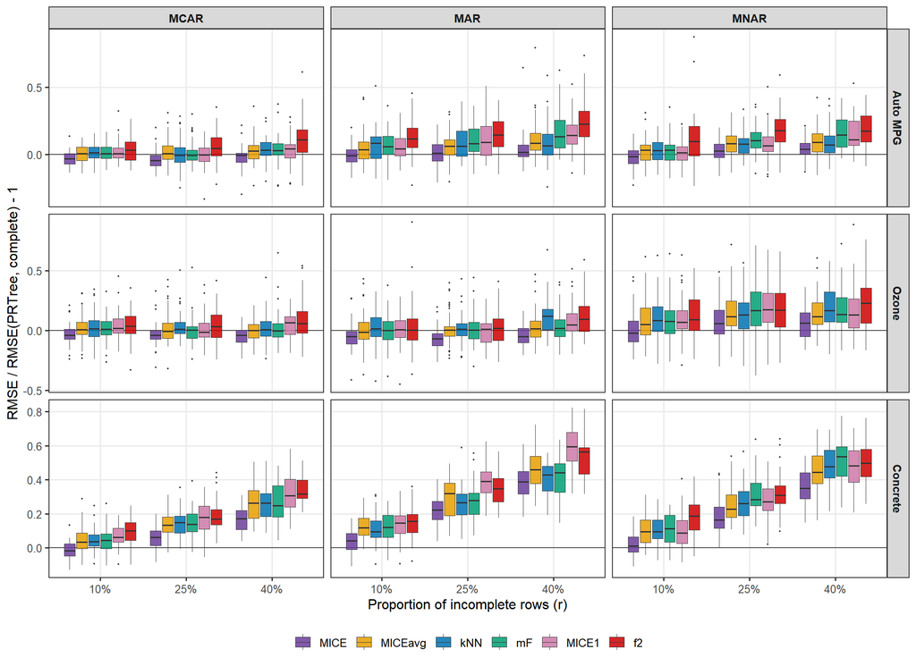

### 3.2 Win-Rate Heatmaps (PR-f2 vs. Competitors)

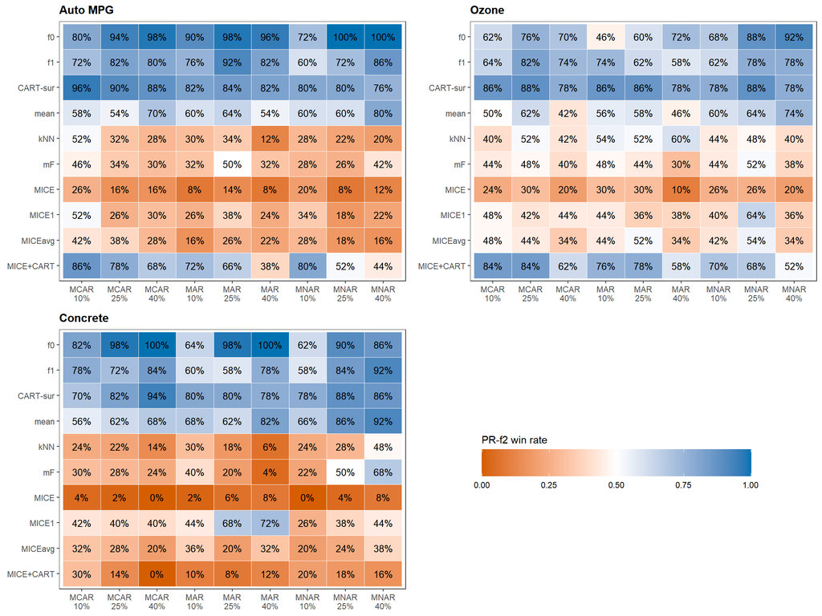

### 3.3 Median Relative Error Summary Table

Scenario 2 (Strong Predictors, Two-Tail): Median (IQR) of relative error for top specifications across datasets. Best (lowest) median error in bold.

| Dataset | Mechanism | Rate | MICE | MICE1 | MICEavg | f2 | kNN | mF |
| --- | --- | --- | --- | --- | --- | --- | --- | --- |
| Auto MPG | MCAR | 10% | **-0.03** (0.08) | 0.01 (0.07) | 0.00 (0.10) | 0.03 (0.13) | 0.01 (0.08) | 0.01 (0.08) |
| Auto MPG | MCAR | 25% | **-0.05** (0.08) | -0.00 (0.10) | 0.01 (0.10) | 0.04 (0.14) | -0.01 (0.11) | -0.01 (0.08) |
| Auto MPG | MCAR | 40% | **-0.01** (0.07) | 0.04 (0.10) | 0.02 (0.10) | 0.11 (0.17) | 0.03 (0.10) | 0.03 (0.08) |
| Auto MPG | MAR | 10% | **-0.01** (0.09) | 0.04 (0.13) | 0.03 (0.12) | 0.12 (0.15) | 0.08 (0.16) | 0.06 (0.13) |
| Auto MPG | MAR | 25% | **0.01** (0.12) | 0.09 (0.22) | 0.06 (0.12) | 0.14 (0.19) | 0.06 (0.19) | 0.08 (0.17) |
| Auto MPG | MAR | 40% | **0.02** (0.09) | 0.14 (0.14) | 0.08 (0.13) | 0.22 (0.19) | 0.06 (0.16) | 0.13 (0.21) |
| Auto MPG | MNAR | 10% | **-0.02** (0.10) | 0.01 (0.10) | 0.03 (0.11) | 0.10 (0.22) | 0.03 (0.13) | 0.03 (0.11) |
| Auto MPG | MNAR | 25% | **0.03** (0.10) | 0.06 (0.11) | 0.08 (0.12) | 0.18 (0.17) | 0.08 (0.11) | 0.10 (0.11) |
| Auto MPG | MNAR | 40% | **0.04** (0.08) | 0.11 (0.18) | 0.09 (0.13) | 0.18 (0.19) | 0.07 (0.13) | 0.15 (0.20) |
| Ozone | MCAR | 10% | **-0.04** (0.08) | 0.02 (0.12) | 0.01 (0.10) | 0.04 (0.14) | 0.02 (0.13) | 0.01 (0.11) |
| Ozone | MCAR | 25% | **-0.04** (0.07) | -0.01 (0.11) | -0.01 (0.13) | 0.03 (0.19) | 0.01 (0.10) | 0.01 (0.10) |
| Ozone | MCAR | 40% | **-0.04** (0.10) | 0.06 (0.15) | -0.00 (0.11) | 0.06 (0.18) | 0.01 (0.12) | -0.00 (0.11) |
| Ozone | MAR | 10% | **-0.05** (0.11) | 0.01 (0.14) | -0.01 (0.14) | 0.00 (0.18) | 0.02 (0.16) | -0.00 (0.15) |
| Ozone | MAR | 25% | **-0.07** (0.10) | 0.01 (0.16) | 0.00 (0.08) | 0.02 (0.18) | 0.01 (0.10) | 0.01 (0.14) |
| Ozone | MAR | 40% | **-0.05** (0.12) | 0.05 (0.14) | 0.01 (0.14) | 0.09 (0.21) | 0.12 (0.17) | 0.02 (0.14) |
| Ozone | MNAR | 10% | **-0.02** (0.18) | 0.07 (0.15) | 0.05 (0.23) | 0.09 (0.26) | 0.09 (0.21) | 0.08 (0.19) |
| Ozone | MNAR | 25% | **0.06** (0.20) | 0.17 (0.25) | 0.11 (0.21) | 0.17 (0.28) | 0.13 (0.22) | 0.17 (0.28) |
| Ozone | MNAR | 40% | **0.06** (0.20) | 0.13 (0.25) | 0.12 (0.18) | 0.23 (0.29) | 0.17 (0.25) | 0.14 (0.21) |
| Concrete | MCAR | 10% | **-0.02** (0.07) | 0.06 (0.08) | 0.03 (0.09) | 0.10 (0.11) | 0.04 (0.07) | 0.04 (0.09) |
| Concrete | MCAR | 25% | **0.06** (0.09) | 0.18 (0.13) | 0.13 (0.09) | 0.17 (0.09) | 0.15 (0.10) | 0.14 (0.10) |
| Concrete | MCAR | 40% | **0.17** (0.11) | 0.31 (0.16) | 0.26 (0.17) | 0.32 (0.11) | 0.26 (0.14) | 0.25 (0.18) |
| Concrete | MAR | 10% | **0.04** (0.09) | 0.14 (0.10) | 0.12 (0.10) | 0.16 (0.11) | 0.09 (0.10) | 0.12 (0.13) |
| Concrete | MAR | 25% | **0.22** (0.11) | 0.39 (0.12) | 0.32 (0.19) | 0.35 (0.14) | 0.27 (0.12) | 0.28 (0.12) |
| Concrete | MAR | 40% | **0.39** (0.13) | 0.59 (0.17) | 0.46 (0.16) | 0.56 (0.16) | 0.43 (0.14) | 0.44 (0.17) |
| Concrete | MNAR | 10% | **0.01** (0.09) | 0.09 (0.14) | 0.09 (0.13) | 0.19 (0.15) | 0.09 (0.11) | 0.11 (0.16) |
| Concrete | MNAR | 25% | **0.16** (0.12) | 0.27 (0.13) | 0.23 (0.13) | 0.31 (0.10) | 0.26 (0.14) | 0.28 (0.13) |
| Concrete | MNAR | 40% | **0.35** (0.15) | 0.48 (0.19) | 0.44 (0.16) | 0.50 (0.16) | 0.48 (0.16) | 0.54 (0.17) |